```python
%matplotlib inline
```

# Comparison of ensembling classifiers internally using sampling

We make a comparison using the balanced accuracy and geometric mean which are metrics widely used in the literature to evaluate models learned on imbalanced set.

```python
# Authors: Guillaume Lemaitre <g.lemaitre58@gmail.com>
# License: MIT

import itertools

import matplotlib.pyplot as plt
import numpy as np

from sklearn.model_selection import train_test_split
from sklearn.ensemble import BaggingClassifier
from sklearn.ensemble import RandomForestClassifier
from sklearn.ensemble import AdaBoostClassifier
from sklearn.tree import DecisionTreeClassifier
from sklearn.metrics import confusion_matrix
from sklearn.metrics import balanced_accuracy_score

from imblearn.datasets import fetch_datasets
from imblearn.ensemble import BalancedBaggingClassifier
from imblearn.ensemble import BalancedRandomForestClassifier
from imblearn.ensemble import EasyEnsembleClassifier
from imblearn.ensemble import RUSBoostClassifier

from imblearn.metrics import geometric_mean_score
from sklearn.model_selection import GridSearchCV
from sklearn.metrics import f1_score
```

# F1 Score warning

When true positive + false positive == 0, precision is undefined; When true positive + false negative == 0, recall is undefined. In such cases, by default the metric will be set to 0, as will f-score, and UndefinedMetricWarning will be raised. This behavior can be modified with zero_division.

```python
def plot_confusion_matrix(cm, classes, ax,
                          normalize=False,
                          title='Confusion matrix',
                          cmap=plt.cm.Blues):
    """
    This function prints and plots the confusion matrix.
    Normalization can be applied by setting `normalize=True`.
    """
    print(cm)
    print('')

    ax.imshow(cm, interpolation='nearest', cmap=cmap)
    ax.set_title(title)
    tick_marks = np.arange(len(classes))
    plt.xticks(tick_marks, classes, rotation=45)
    plt.sca(ax)
    plt.yticks(tick_marks, classes)

    fmt = '.2f' if normalize else 'd'
    thresh = cm.max() / 2.
    for i, j in itertools.product(range(cm.shape[0]), range(cm.shape[1])):
        ax.text(j, i, format(cm[i, j], fmt),
                horizontalalignment="center",
                color="white" if cm[i, j] > thresh else "black")

    ax.set_ylabel('True label')
    ax.set_xlabel('Predicted label')
```

```python
# importing our favorite libraries
import numpy as np
import pandas as pd

from sklearn.model_selection import train_test_split
from sklearn.metrics import f1_score,accuracy_score
```

Load an imbalanced dataset

```python
df_p = pd.read_excel (r'C:\Users\vince\Desktop\Jupiter\DMV_Crash_Data_Bool.xlsx', skip_header = True)
print(df_p.head())
print((df_p).shape)
```

```
  Company       Date      Time  Relative speed(mph)  vehicle type  \
0  Delphi 2014-10-14  19:27:00                 28.0           2.0
1  Google 2015-02-26       NaN                  NaN           3.0
2  Google 2015-04-07       NaN                  5.0           2.0
3  Google 2015-04-27  16:27:00                  NaN           3.0
4  Google 2015-05-30  12:00:00                  1.0           3.0

  Vehicle make Vehicle model       Road type  Number for Road Type  \
0          NaN           NaN            road                   2.0
1        Lexus        RX450h          street                   1.0
2        Lexus        RX450h          street                   1.0
3        Lexus        RX450h          street                   1.0
4        Lexus        RX450h  shoreline blvd                   4.0

                            Address  ... Collision Type AV  \
```

[output cut: 36 more lines]

```python
filtered_df = (df_p["vehicle type"], df_p["Number for Road Type"], df_p["Intersection"],
    df_p["Intersection Geometry"], df_p["Parking provision"], df_p["Mode"],
    df_p["Vehicle1 Status"], df_p["Fault"], df_p["NO. for collision type"],
    df_p["InjuriesBool"], df_p["Vehicle1 Damage"], df_p["Vehicle2 Damage"], df_p["signal"])
df_p = pd.DataFrame(data = filtered_df)
print(type(df_p))
print(df_p.head())
df_p = df_p.transpose()
print(type(df_p))
#print(df_p)
```

```
<class 'pandas.core.frame.DataFrame'>
                       0    1    2    3    4    5    6    7    8    9    ...  \
vehicle type           2.0  3.0  2.0  3.0  3.0  3.0  2.0  3.0  3.0  2.0  ...
Number for Road Type   2.0  1.0  1.0  1.0  4.0  1.0  1.0  2.0  4.0  1.0  ...
Intersection           0.0  1.0  1.0  1.0  1.0  1.0  1.0  1.0  1.0  1.0  ...
Intersection Geometry  2.0  2.0  3.0  3.0  0.0  3.0  3.0  3.0  2.0  2.0  ...
Parking provision      0.0  1.0  1.0  1.0  1.0  1.0  1.0  0.0  1.0  1.0  ...

                       249  250  251  252  253  254  255  256  257  258
vehicle type           3.0  4.0  2.0  4.0  2.0  2.0  4.0  3.0  4.0  3.0
Number for Road Type   2.0  1.0  1.0  1.0  1.0  3.0  1.0  2.0  1.0  1.0
Intersection           0.0  1.0  1.0  0.0  0.0  1.0  1.0  1.0  1.0  1.0
Intersection Geometry  3.0  2.0  3.0  3.0  3.0  1.0  1.0  3.0  3.0  2.0
Parking provision      1.0  1.0  1.0  1.0  1.0  0.0  0.0  0.0  1.0  0.0

[5 rows x 259 columns]
<class 'pandas.core.frame.DataFrame'>
```

```python
#remove Na values

df_R = df_p.dropna(axis=0) #axis=0
#Determine if rows or columns which contain missing values are removed.
#0, or ‘index’ : Drop rows which contain missing values.
print((df_R).shape)
print(df_R.head())
```

```
(202, 13)
   vehicle type  Number for Road Type  Intersection  Intersection Geometry  \
0           2.0                   2.0           0.0                    2.0
1           3.0                   1.0           1.0                    2.0
2           2.0                   1.0           1.0                    3.0
3           3.0                   1.0           1.0                    3.0
4           3.0                   4.0           1.0                    0.0

   Parking provision  Mode  Vehicle1 Status  Fault  NO. for collision type  \
0                0.0   0.0              0.0    0.0                     2.0
1                1.0   0.0              1.0    0.0                     3.0
2                1.0   1.0              1.0    0.0                     2.0
3                1.0   1.0              0.0    0.0                     2.0
4                1.0   1.0              0.0    0.0                     3.0

   InjuriesBool  Vehicle1 Damage  Vehicle2 Damage  signal
0           0.0              4.0              1.0     0.0
1           0.0              1.0              1.0     0.0
2           0.0              3.0              1.0     1.0
3           0.0              2.0              2.0     1.0
4           0.0              3.0              2.0     1.0
```

```python
X_df = (df_R["vehicle type"], df_R["Number for Road Type"], df_R["Intersection"],
    df_R["Intersection Geometry"], df_R["Parking provision"], df_R["Mode"],
    df_R["Vehicle1 Status"], df_R["Fault"], df_R["NO. for collision type"],
    df_R["Vehicle1 Damage"], df_R["Vehicle2 Damage"], df_R["signal"])
print(type(X_df))
print(len(X_df))
X_np= np.asarray(X_df)
print(type(X_np))
print((X_np).shape)
X_np= np.transpose(X_df)
print(type(X_np))
print((X_np).shape)
```

```
<class 'tuple'>
12
<class 'numpy.ndarray'>
(12, 202)
<class 'numpy.ndarray'>
(202, 12)
```

```python
#Please enter the dependent variables
Y_df = (df_R["InjuriesBool"])
print(type(Y_df))
print(len(Y_df))
Y_np= np.asarray(Y_df)
print(type(Y_np))
print((Y_np).shape)
Y_np= np.transpose(Y_df)
print(type(Y_np))
print((Y_np).shape)
```

```
<class 'pandas.core.series.Series'>
202
<class 'numpy.ndarray'>
(202,)
<class 'pandas.core.series.Series'>
(202,)
```

```python
X_train, X_test, y_train, y_test = train_test_split(X_np, Y_np,
                                                    test_size=0.20,
                                                    random_state=42, stratify = Y_np)
```

```python
my_class = [-1,  1]
```

```python
#finding class weight
class_weight = int(y_train.value_counts()[0]/y_train.value_counts()[1])
class_weight
```

```
5
```

Classification using a single decision tree

We train a decision tree classifier which will be used as a baseline for the rest of this example.

The results are reported in terms of balanced accuracy and geometric mean which are metrics widely used in the literature to validate model trained on imbalanced set.

```
Decision tree classifier performance:
Balanced accuracy: 0.62 - Geometric mean 0.55
F1 Score: 0.3636363636363636
[[32  3]
 [ 4  2]]
```

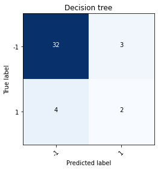

```python
tree = DecisionTreeClassifier()
tree.fit(X_train, y_train)
y_pred_tree = tree.predict(X_test)
print('Decision tree classifier performance:')
print('Balanced accuracy: {:.2f} - Geometric mean {:.2f}'
      .format(balanced_accuracy_score(y_test, y_pred_tree),
              geometric_mean_score(y_test, y_pred_tree)))
print("F1 Score: " + str(f1_score(y_test,y_pred_tree)))
cm_tree = confusion_matrix(y_test, y_pred_tree)
fig, ax = plt.subplots()
plot_confusion_matrix(cm_tree, classes=my_class, ax=ax,
                      title='Decision tree')
```

```python
gridsearch_forest = DecisionTreeClassifier() #defining type of model _ aim to find the best parameters

params = { #"class_weight": [{0:1,1:class_weight}, {0:1,1:8}, {0:1,1:10}],
          #"n_estimators": [40, 100,300],
          "max_features": ["sqrt", "log2", "auto"]
          #"max_depth": [5,8,15],
          #"min_samples_leaf" : [1, 2, 4],

#"bootstrap": [True, False],

#"ccp_alpha": [0.0, 1.0],

#"criterion": ['mse', 'mae'], "max_depth" : [5, 8, 15], "max_features" :['auto', 'sqrt', 'log2', 2],

#"max_leaf_nodes" = None,

#"max_samples" = None,

#"min_impurity_decrease"0.0,

#"min_impurity_split":None, "min_samples_leaf": [1, 2, 3, 4, 5], "min_samples_split": [2,3],

#"min_weight_fraction_leaf" : 0.0, "n_jobs": [4,-1],

#n_estimators=100, n_jobs=None,

#oob_score=False,

#random_state=None,

#verbose=0, warm_start=False
         }

clf = GridSearchCV(gridsearch_forest, param_grid=params, cv=5 )
clf.fit(X_train, y_train)
print(clf.best_params_)
print(clf.best_score_)
```

```
{'max_features': 'auto'}
0.7573863636363637
```

```
Decision tree classifier performance:
Balanced accuracy: 0.62 - Geometric mean 0.55
F1 Score: 0.3636363636363636
[[32  3]
 [ 4  2]]
```

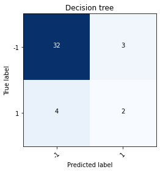

```python
tree = DecisionTreeClassifier(max_features = "auto")  #INSERT THE BEST PARAMETER
tree.fit(X_train, y_train)
y_pred_tree = tree.predict(X_test)
print('Decision tree classifier performance:')
print('Balanced accuracy: {:.2f} - Geometric mean {:.2f}'
      .format(balanced_accuracy_score(y_test, y_pred_tree),
              geometric_mean_score(y_test, y_pred_tree)))
print("F1 Score: " + str(f1_score(y_test,y_pred_tree)))
cm_tree = confusion_matrix(y_test, y_pred_tree)
fig, ax = plt.subplots()
plot_confusion_matrix(cm_tree, classes=my_class, ax=ax,
                      title='Decision tree')
```

# Decision Tree Classifier with Weights

```
Decision tree classifier performance:
Balanced accuracy: 0.68 - Geometric mean 0.65
F1 Score: 0.42857142857142855
[[30  5]
 [ 3  3]]
```

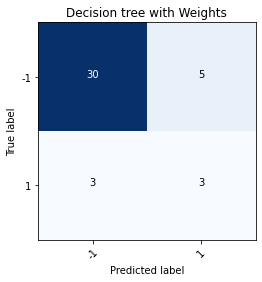

```python
tree = DecisionTreeClassifier(class_weight= {0:1,1:class_weight})
tree.fit(X_train, y_train)
y_pred_tree = tree.predict(X_test)
print('Decision tree classifier performance:')
print('Balanced accuracy: {:.2f} - Geometric mean {:.2f}'
      .format(balanced_accuracy_score(y_test, y_pred_tree),
              geometric_mean_score(y_test, y_pred_tree)))
print("F1 Score: " + str(f1_score(y_test,y_pred_tree)))
cm_tree = confusion_matrix(y_test, y_pred_tree)
fig, ax = plt.subplots()
plot_confusion_matrix(cm_tree, classes=my_class, ax=ax,
                      title='Decision tree with Weights')
```

```python
gridsearch_forest = DecisionTreeClassifier()

params = { "class_weight": [{0:1,1:class_weight}, {0:1,1:8}, {0:1,1:10}],
          #"n_estimators": [10, 25, 50, 75],
          #"n_estimators": [40, 100,300],
          "max_features": ["sqrt", "log2", "auto"]
          #"max_depth": [5,8,15],
          #"min_samples_leaf" : [1, 2, 4],

#"bootstrap": [True, False],

#"ccp_alpha": [0.0, 1.0],

#"criterion": ['mse', 'mae'], "max_depth" : [5, 8, 15], "max_features" :['auto', 'sqrt', 'log2', 2],

#"max_leaf_nodes" = None,

#"max_samples" = None,

#"min_impurity_decrease"0.0,

#"min_impurity_split":None, "min_samples_leaf": [1, 2, 3, 4, 5], "min_samples_split": [2,3],

#"min_weight_fraction_leaf" : 0.0, "n_jobs": [4,-1],

#n_estimators=100, n_jobs=None,

#oob_score=False,

#random_state=None,

#verbose=0, warm_start=False
         }

clf = GridSearchCV(gridsearch_forest, param_grid=params, cv=5 )
clf.fit(X_train, y_train)
print(clf.best_params_)
print(clf.best_score_)
```

```
{'class_weight': {0: 1, 1: 8}, 'max_features': 'sqrt'}
0.7634469696969697
```

```
Decision tree classifier performance:
Balanced accuracy: 0.51 - Geometric mean 0.38
F1 Score: 0.16666666666666666
[[30  5]
 [ 5  1]]
```

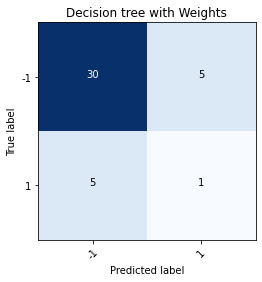

```python
tree = DecisionTreeClassifier(class_weight= {0:1,1:8},max_features = "sqrt")  #Change the class weight and include the best paramter
tree.fit(X_train, y_train)
y_pred_tree = tree.predict(X_test)
print('Decision tree classifier performance:')
print('Balanced accuracy: {:.2f} - Geometric mean {:.2f}'
      .format(balanced_accuracy_score(y_test, y_pred_tree),
              geometric_mean_score(y_test, y_pred_tree)))
print("F1 Score: " + str(f1_score(y_test,y_pred_tree)))
cm_tree = confusion_matrix(y_test, y_pred_tree)
fig, ax = plt.subplots()
plot_confusion_matrix(cm_tree, classes=my_class, ax=ax,
                      title='Decision tree with Weights')
```

# Bagging

(https://scikit-learn.org/stable/modules/generated/sklearn.ensemble.BaggingClassifier.html)

Classification using bagging classifier with and without sampling

Instead of using a single tree, we will check if an ensemble of decsion tree can actually alleviate the issue induced by the class imbalancing. First, we will use a bagging classifier and its counter part which internally uses a random under-sampling to balanced each boostrap sample.

```
Bagging classifier performance:
Balanced accuracy: 0.55 - Geometric mean 0.40
F1 Score: 0.2222222222222222
[[33  2]
 [ 5  1]]
```

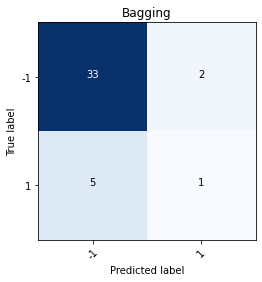

```python
bagging = BaggingClassifier(n_estimators=50, random_state=0)
bagging.fit(X_train, y_train)
y_pred_bc = bagging.predict(X_test)


print('Bagging classifier performance:')
print('Balanced accuracy: {:.2f} - Geometric mean {:.2f}'
      .format(balanced_accuracy_score(y_test, y_pred_bc),
              geometric_mean_score(y_test, y_pred_bc)))
print("F1 Score: " + str(f1_score(y_test,y_pred_bc)))
cm_bagging = confusion_matrix(y_test, y_pred_bc)
fig, ax = plt.subplots(ncols=1)
plot_confusion_matrix(cm_bagging, classes=my_class, ax=ax,
                      title='Bagging')
```

```python
gridsearch_forest = BaggingClassifier()

params = { #"class_weight": [{0:1,1:class_weight}, {0:1,1:8}, {0:1,1:10}],
          "n_estimators": [5,10,15,20,25,30,35,40,45,50,55,60,65,70,75,80,85,90,95,100],
          #"max_features": ["sqrt", "log2", "None"],
          "oob_score":['False', 'True']
          #"max_depth": [5,8,15],
          #"min_samples_leaf" : [1, 2, 4],

#"bootstrap": [True, False],

#"ccp_alpha": [0.0, 1.0],

#"criterion": ['mse', 'mae'], "max_depth" : [5, 8, 15], "max_features" :['auto', 'sqrt', 'log2', 2],

#"max_leaf_nodes" = None,

#"max_samples" = None,

#"min_impurity_decrease"0.0,

#"min_impurity_split":None, "min_samples_leaf": [1, 2, 3, 4, 5], "min_samples_split": [2,3],

#"min_weight_fraction_leaf" : 0.0, "n_jobs": [4,-1],

#n_estimators=100, n_jobs=None,



#random_state=None,

#verbose=0, warm_start=False
         }

clf = GridSearchCV(gridsearch_forest, param_grid=params, cv=5 )
clf.fit(X_train, y_train)
print(clf.best_params_)
print(clf.best_score_)
```

[output not shown]

[output cut: 17 more lines]

[output not shown]

```
{'n_estimators': 20, 'oob_score': 'False'}
0.8009469696969698
```

```
Bagging classifier performance:
Balanced accuracy: 0.65 - Geometric mean 0.57
F1 Score: 0.4444444444444444
[[34  1]
 [ 4  2]]
```

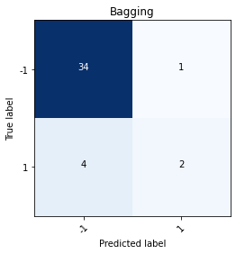

```python
bagging = BaggingClassifier(n_estimators=20, random_state=0) #choose the parameter and keep random_state=0
#random state default=None
bagging.fit(X_train, y_train)
y_pred_bc = bagging.predict(X_test)


print('Bagging classifier performance:')
print('Balanced accuracy: {:.2f} - Geometric mean {:.2f}'
      .format(balanced_accuracy_score(y_test, y_pred_bc),
              geometric_mean_score(y_test, y_pred_bc)))
print("F1 Score: " + str(f1_score(y_test,y_pred_bc)))
cm_bagging = confusion_matrix(y_test, y_pred_bc)
fig, ax = plt.subplots(ncols=1)
plot_confusion_matrix(cm_bagging, classes=my_class, ax=ax,
                      title='Bagging')
```

# Balanced Bagging

(https://imbalanced-learn.readthedocs.io/en/stable/generated/imblearn.ensemble.BalancedBaggingClassifier.html)

```
Balanced Bagging classifier performance:
Balanced accuracy: 0.58 - Geometric mean 0.57
F1 Score: 0.28571428571428575
[[23 12]
 [ 3  3]]
```

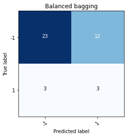

```python
balanced_bagging = BalancedBaggingClassifier(n_estimators=50, random_state=0)
balanced_bagging.fit(X_train, y_train)
y_pred_bbc = balanced_bagging.predict(X_test)
print('Balanced Bagging classifier performance:')
print('Balanced accuracy: {:.2f} - Geometric mean {:.2f}'
      .format(balanced_accuracy_score(y_test, y_pred_bbc),
              geometric_mean_score(y_test, y_pred_bbc)))
print("F1 Score: " + str(f1_score(y_test,y_pred_bbc)))
cm_balanced_bagging = confusion_matrix(y_test, y_pred_bbc)
fig, ax = plt.subplots(ncols=1)
plot_confusion_matrix(cm_balanced_bagging, classes=my_class,
                      ax=ax, title='Balanced bagging')
```

```python
gridsearch_forest = BalancedBaggingClassifier()

params = { #"class_weight": [{0:1,1:class_weight}, {0:1,1:8}, {0:1,1:10}],
          "n_estimators": [5,10,15,20,25,30,35,40,45,50,55,60,65,70,75,80,85,90,95,100],
          #"max_features": ["sqrt", "log2", "auto"],
          "oob_score": ['False', 'True'],
          #"max_depth": [5,8,15],
          #"min_samples_leaf" : [1, 2, 4],

#"bootstrap": [True, False],

#"ccp_alpha": [0.0, 1.0],

#"criterion": ['mse', 'mae'], "max_depth" : [5, 8, 15], "max_features" :['auto', 'sqrt', 'log2', 2],

#"max_leaf_nodes" = None,

#"max_samples" = None,

#"min_impurity_decrease"0.0,

#"min_impurity_split":None, "min_samples_leaf": [1, 2, 3, 4, 5], "min_samples_split": [2,3],

#"min_weight_fraction_leaf" : 0.0, "n_jobs": [4,-1],

#n_estimators=100, n_jobs=None,



#random_state=None,

#verbose=0, warm_start=False
         }

clf = GridSearchCV(gridsearch_forest, param_grid=params, cv=5 )
clf.fit(X_train, y_train)
print(clf.best_params_)
print(clf.best_score_)
```

[output not shown]

[output cut: 20 more lines]

```
{'n_estimators': 95, 'oob_score': 'True'}
0.7136363636363636
```

```
Balanced Bagging classifier performance:
Balanced accuracy: 0.59 - Geometric mean 0.59
F1 Score: 0.3
[[24 11]
 [ 3  3]]
```

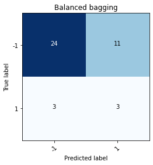

```python
balanced_bagging = BalancedBaggingClassifier(n_estimators=95, random_state=0) #choose the parameter and keep random_state=0
balanced_bagging.fit(X_train, y_train)
y_pred_bbc = balanced_bagging.predict(X_test)
print('Balanced Bagging classifier performance:')
print('Balanced accuracy: {:.2f} - Geometric mean {:.2f}'
      .format(balanced_accuracy_score(y_test, y_pred_bbc),
              geometric_mean_score(y_test, y_pred_bbc)))
print("F1 Score: " + str(f1_score(y_test,y_pred_bbc)))
cm_balanced_bagging = confusion_matrix(y_test, y_pred_bbc)
fig, ax = plt.subplots(ncols=1)
plot_confusion_matrix(cm_balanced_bagging, classes=my_class,
                      ax=ax, title='Balanced bagging')
```

# Random Forest

(https://scikit-learn.org/stable/modules/generated/sklearn.ensemble.RandomForestClassifier.html)

Classification using random forest classifier with and without sampling

Random forest is another popular ensemble method and it is usually outperforming bagging. Here, we used a vanilla random forest and its balanced counterpart in which each bootstrap sample is balanced.

```
Random Forest classifier performance:
Balanced accuracy: 0.55 - Geometric mean 0.40
F1 Score: 0.2222222222222222
[[33  2]
 [ 5  1]]
```

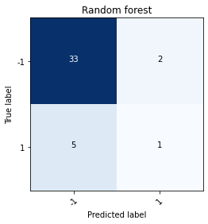

```python
rf = RandomForestClassifier(n_estimators=50, random_state=0)


rf.fit(X_train, y_train)


y_pred_rf = rf.predict(X_test)


# Similarly to the previous experiment, the balanced classifier outperform the
# classifier which learn from imbalanced bootstrap samples. In addition, random
# forest outsperforms the bagging classifier.

print('Random Forest classifier performance:')
print('Balanced accuracy: {:.2f} - Geometric mean {:.2f}'
      .format(balanced_accuracy_score(y_test, y_pred_rf),
              geometric_mean_score(y_test, y_pred_rf)))
print("F1 Score: " + str(f1_score(y_test,y_pred_rf)))
cm_rf = confusion_matrix(y_test, y_pred_rf)
fig, ax = plt.subplots(ncols=1)
plot_confusion_matrix(cm_rf, classes=my_class, ax=ax,
                      title='Random forest')
```

```python
gridsearch_forest = RandomForestClassifier()

params = { "class_weight": [{0:1,1:class_weight}, {0:1,1:8}, {0:1,1:10}],
          "n_estimators": [5,10,15,20,25,30,35,40,45,50,55,60,65,70,75,80,85,90,95,100],
          "max_features": ["sqrt", "log2", "auto"],
          "oob_score": ['False', 'True'],
          #"max_depth": [5,8,15],
          #"min_samples_leaf" : [1, 2, 4],

#"bootstrap": [True, False],

#"ccp_alpha": [0.0, 1.0],

#"criterion": ['mse', 'mae'], "max_depth" : [5, 8, 15], "max_features" :['auto', 'sqrt', 'log2', 2],

#"max_leaf_nodes" = None,

#"max_samples" = None,

#"min_impurity_decrease"0.0,

#"min_impurity_split":None, "min_samples_leaf": [1, 2, 3, 4, 5], "min_samples_split": [2,3],

#"min_weight_fraction_leaf" : 0.0, "n_jobs": [4,-1],

#n_estimators=100, n_jobs=None,



#random_state=None,

#verbose=0, warm_start=False
         }

clf = GridSearchCV(gridsearch_forest, param_grid=params, cv=5 )
clf.fit(X_train, y_train)
print(clf.best_params_)
print(clf.best_score_)
```

[output not shown]

[output cut: 621 more lines]

[output not shown]

```
{'class_weight': {0: 1, 1: 5}, 'max_features': 'auto', 'n_estimators': 10, 'oob_score': 'True'}
0.8261363636363637
```

```
Random Forest classifier performance:
Balanced accuracy: 0.57 - Geometric mean 0.40
F1 Score: 0.25
[[34  1]
 [ 5  1]]
```

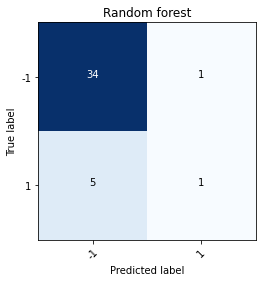

```python
rf = RandomForestClassifier(n_estimators=10, max_features = "auto"
                            , class_weight = {0:1,1:5}, random_state=0)  #choose the parameter and keep random_state=0
#n_estimators, default=100

rf.fit(X_train, y_train)

y_pred_rf = rf.predict(X_test)

# Similarly to the previous experiment, the balanced classifier outperform the
# classifier which learn from imbalanced bootstrap samples. In addition, random
# forest outsperforms the bagging classifier.

print('Random Forest classifier performance:')
print('Balanced accuracy: {:.2f} - Geometric mean {:.2f}'
      .format(balanced_accuracy_score(y_test, y_pred_rf),
              geometric_mean_score(y_test, y_pred_rf)))
print("F1 Score: " + str(f1_score(y_test,y_pred_rf)))
cm_rf = confusion_matrix(y_test, y_pred_rf)
fig, ax = plt.subplots(ncols=1)
plot_confusion_matrix(cm_rf, classes=my_class, ax=ax,
                      title='Random forest')
```

# Balanced Random Forest

(https://imbalanced-learn.readthedocs.io/en/stable/generated/imblearn.ensemble.BalancedRandomForestClassifier.html)

```
Balanced Random Forest classifier performance:
Balanced accuracy: 0.49 - Geometric mean 0.49
F1 Score: 0.22222222222222224
[[17 18]
 [ 3  3]]
```

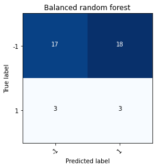

```python
brf = BalancedRandomForestClassifier(n_estimators=50, random_state=0, class_weight= {0:1,1:class_weight})
brf.fit(X_train, y_train)
y_pred_brf = brf.predict(X_test)

# Similarly to the previous experiment, the balanced classifier outperform the
# classifier which learn from imbalanced bootstrap samples. In addition, random
# forest outsperforms the bagging classifier.
print('Balanced Random Forest classifier performance:')
print('Balanced accuracy: {:.2f} - Geometric mean {:.2f}'
      .format(balanced_accuracy_score(y_test, y_pred_brf),
              geometric_mean_score(y_test, y_pred_brf)))
print("F1 Score: " + str(f1_score(y_test,y_pred_brf)))
cm_brf = confusion_matrix(y_test, y_pred_brf)
fig, ax = plt.subplots(ncols=1)
plot_confusion_matrix(cm_brf, classes=my_class, ax=ax,
                      title='Balanced random forest')
```

```python
gridsearch_forest = BalancedRandomForestClassifier()

params = {"class_weight": [{0:1,1:class_weight}, {0:1,1:8}, {0:1,1:10}],
          "n_estimators": [5,10,15,20,25,30,35,40,45,50,55,60,65,70,75,80,85,90,95,100],
          "max_features": ["sqrt", "log2", "auto"],
          "oob_score": ['False', 'True'],
          #"max_depth": [5,8,15],
          #"min_samples_leaf" : [1, 2, 4],

#"bootstrap": [True, False],

#"ccp_alpha": [0.0, 1.0],

#"criterion": ['mse', 'mae'], "max_depth" : [5, 8, 15], "max_features" :['auto', 'sqrt', 'log2', 2],

#"max_leaf_nodes" = None,

#"max_samples" = None,

#"min_impurity_decrease"0.0,

#"min_impurity_split":None, "min_samples_leaf": [1, 2, 3, 4, 5], "min_samples_split": [2,3],

#"min_weight_fraction_leaf" : 0.0, "n_jobs": [4,-1],

#n_estimators=100, n_jobs=None,



#random_state=None,

#verbose=0, warm_start=False
         }

clf = GridSearchCV(gridsearch_forest, param_grid=params, cv=5 )
clf.fit(X_train, y_train)
print(clf.best_params_)
print(clf.best_score_)
```

[output not shown]

[output cut: 2705 more lines]

[output not shown]

```
{'class_weight': {0: 1, 1: 10}, 'max_features': 'sqrt', 'n_estimators': 20, 'oob_score': 'False'}
0.6821969696969697
```

```
Balanced Random Forest classifier performance:
Balanced accuracy: 0.38 - Geometric mean 0.32
F1 Score: 0.09523809523809522
[[21 14]
 [ 5  1]]
```

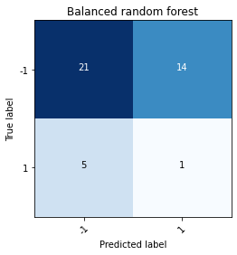

```python
brf = BalancedRandomForestClassifier(n_estimators=20, max_features = "sqrt",
                                     random_state=0, class_weight= {0:1,1:10}) #Use the best parameter and keep random_state =0
brf.fit(X_train, y_train)
y_pred_brf = brf.predict(X_test)

# Similarly to the previous experiment, the balanced classifier outperform the
# classifier which learn from imbalanced bootstrap samples. In addition, random
# forest outsperforms the bagging classifier.
print('Balanced Random Forest classifier performance:')
print('Balanced accuracy: {:.2f} - Geometric mean {:.2f}'
      .format(balanced_accuracy_score(y_test, y_pred_brf),
              geometric_mean_score(y_test, y_pred_brf)))
print("F1 Score: " + str(f1_score(y_test,y_pred_brf)))
cm_brf = confusion_matrix(y_test, y_pred_brf)
fig, ax = plt.subplots(ncols=1)
plot_confusion_matrix(cm_brf, classes=my_class, ax=ax,
                      title='Balanced random forest')
```